# Car Selling Price - Honda HR-V

- Show All Code
- Hide All Code

Course MATH 425

Author

Lexi Soelberg

```r
# Load your libraries
library(car)
library(pander)
library(tidyverse)
library(dplyr)
library(mosaic)
library(ggplot2)
library(plotly)
library(DT)


# boxcox to figure out which transformation i need
# y prime
# remove prime and put what
# predicted value snap the line back.
#square the prime again after computed value (3rd equation)
# when including boxcox put it away in details and don't present it
# consider log for exponential car
# pick transformation : like the fit (boxcox) or belief system (human logic)
# 3 equations = prime space, what prime is,

carselling <- data.frame(
  Mileage = c(66000, 27165, 98241, 25, 7, 87208, 5, 80655, 86740, 101714, 145715, 66912, 15411, 77509, 72764, 19136, 21394, 11255, 22291, 31084, 103162, 69057, 9567, 67592, 32238, 147099, 192216, 176835, 138436, 3978),
  Price = c(12999, 17500, 16818, 31324, 32350, 15990, 32434, 14950, 16495, 17687, 13295, 17800, 25000, 17596, 18288, 25575, 27998, 29998, 22998, 25998, 17955, 19590, 23998, 18998, 20404, 14250, 14977, 10977, 13499, 30998),
  Year = c(2019, 2019, 2017, 2025, 2025, 2017, 2025, 2019, 2016, 2017, 2017, 2018, 2018, 2023, 2018, 2017, 2022, 2023, 2024, 2021, 2022, 2022, 2021, 2020, 2021, 2021, 2020, 2016, 2016, 2024)
)
```

#### Background

The Honda HR-V was introduced as a compact crossover vehicle in 2016 and therefore finding a vehicle with 200k miles is nearly impossible. This vehicle has existed for less than a decade. The data is limited but interesting. Even the oldest models seem to have upheld their value pretty well over the years. The trim for my car specifically the EX-L has great value.

The cars were found on [KSL.com](https://cars.ksl.com/search/make/Honda/model/HR-V/yearFrom/2016/yearTo/2026/mileageFrom/0/mileageTo/1000000), Cars.com, [Autotrader](https://www.autotrader.com/cars-for-sale/all-cars/honda/hr-v/rockland-id?endYear=2022&zip=83271), and the best website for nation-wide searching was [TrueCar](https://www.truecar.com/used-cars-for-sale/listings/honda/hr-v/location-rexburg-id/?searchRadius=5000&trim=ex-l).

I collected 30 cars, from 5 miles to 192k and from $11k to $32k, years ranging from 2016-2025.

My Car is a 2021 Honda HR-V EX-L AWD. Her name is Rexie.

**Hide Data**

**Show Data**

```r
carselling <- data.frame(
  Mileage = c(66000, 27165, 98241, 25, 7, 87208, 5, 80655, 86740, 101714, 145715, 66912, 15411, 77509, 72764, 19136, 21394, 11255, 22291, 31084, 103162, 69057, 9567, 67592, 32238, 147099, 192216, 176835, 138436, 3978),
  Price = c(12999, 17500, 16818, 31324, 32350, 15990, 32434, 14950, 16495, 17687, 13295, 17800, 25000, 17596, 18288, 25575, 27998, 29998, 22998, 25998, 17955, 19590, 23998, 18998, 20404, 14250, 14977, 10977, 13499, 30998),
  Year = c(2019, 2019, 2017, 2025, 2025, 2017, 2025, 2019, 2016, 2017, 2017, 2018, 2018, 2023, 2018, 2017, 2022, 2023, 2024, 2021, 2022, 2022, 2021, 2020, 2021, 2021, 2020, 2016, 2016, 2024)
)

datatable(carselling, options=list(lengthMenu = c(5,10,15))) %>%
formatStyle(names(carselling), color="mediumseagreen")
```

|  | Mileage | Price | Year |
| --- | --- | --- | --- |
| 1 | 66000 | 12999 | 2019 |
| 2 | 27165 | 17500 | 2019 |
| 3 | 98241 | 16818 | 2017 |
| 4 | 25 | 31324 | 2025 |
| 5 | 7 | 32350 | 2025 |
| 6 | 87208 | 15990 | 2017 |
| 7 | 5 | 32434 | 2025 |
| 8 | 80655 | 14950 | 2019 |
| 9 | 86740 | 16495 | 2016 |
| 10 | 101714 | 17687 | 2017 |

[output cut: 20 more lines]

#### Hypothesis

This analysis attempts to model the price I can expect to sell my car at based on the mileage using a simple linear regression.

$$\underbrace{Y_i}_\text{Predicted Price} = {\beta_0} + {\beta_1} \underbrace{X_i}_\text{Mileage} + \epsilon_i \quad \text{where} \ \epsilon_i \sim N(0, \sigma^2)$$

$$H_0: \beta_1 = 0 \\
H_a: \beta_1 \neq 0$$

$\alpha$ = 0.05

# HR-V Linear Regression

**Normal Regression**

### Graph

```r
carsell.lm <- lm(Price ~ Mileage, data = carselling)
n <- coef(carsell.lm)

mypred.cc <- predict(carsell.lm, data.frame(Mileage=21000), interval="confidence")
mypred.cp <- predict(carsell.lm, data.frame(Mileage=21000), interval="prediction")


carsellm.log <- lm(log(Price) ~ Mileage, data = carselling)
b.log <- coef(carsellm.log)


carsell.lm <- lm(Price ~ Mileage, data = carselling)
n <- coef(carsell.lm)


mypred.c <- exp(predict(carsellm.log, data.frame(Mileage=120000), interval="confidence"))
mypred.p <- exp(predict(carsellm.log, data.frame(Mileage=120000), interval="prediction"))


carsell.ggplot <- ggplot(carselling, aes(y = Price, x = Mileage, color = Price, label = Year)) +
  geom_point(pch = 16, bg = "white", size = 3) +
  stat_function(fun = function(x) n[1] + n[2] * x, color = "lightseagreen", size = 1.5) +

  stat_function(fun = function(x) exp(b.log[1] + b.log[2] * x), color = "cadetblue1", size = 1.5) +
  scale_color_gradient(low = "steelblue1", high = "steelblue4") +
  labs(
    title = "Honda HR-V EX-L Prices and Mileages Over The Years<br><sup>2016 - 2025</sup>",
    x = "Mileage",
    y = "Price ($)"
  ) +
  ylim(5000, 40000) +
  theme_light() +
  geom_text(
    aes(x = 21000, y = 16000, label = "My Car"),
    color = "forestgreen", nudge_y = -2000, size = 3.75
  ) +
  geom_point(
    aes(x = 21000, y = 16000, label = 2021),
    color = "forestgreen", size = 3.5
  ) +
  geom_point(
    aes(x = 120000, y = predict(carsell.lm, data.frame(Mileage = 120000, label = 2021))),
    color = "darkgoldenrod2", size = 3.5
  ) +
  geom_text(
    aes(x = 120000, y = predict(carsell.lm, data.frame(Mileage = 120000)),
        label = "When I Sell My Car"),
    color = "darkgoldenrod3", nudge_y = -2500, nudge_x = -10000,  size = 3.75
  ) +
geom_segment(
  aes(x = 21000, y = 16000, xend = 120000, yend = predict(carsell.lm, data.frame(Mileage = 120000))),
  color = "goldenrod", lwd = 1
) +
  geom_point() +
  stat_function(fun=function(x) exp(n[1] + n[2]*x)) +
  geom_segment(aes(x=120000, xend=120000, y=mypred.c[2], yend=mypred.c[3]),
               alpha=0.1, color="goldenrod2", lwd=3) +
  geom_segment(aes(x=120000, xend=120000, y=mypred.p[2], yend=mypred.p[3]),
               alpha=0.01, color="firebrick", lwd=2)+
  geom_point() +
  stat_function(fun=function(x) exp(n[1] + n[2]*x)) +
  geom_segment(aes(x=21000, xend=21000, y=mypred.cc[2], yend=mypred.cc[3]),
               alpha=0.1, color="forestgreen", lwd=3) +
  geom_segment(aes(x=21000, xend=21000, y=mypred.cp[2], yend=mypred.cp[3]),
               alpha=0.01, color="steelblue", lwd=2)

ggplotly(carsell.ggplot, tooltip = c("y", "x", "label"))
```

[interactive chart not shown]

```r
CarSellPredict <- predict(carsell.lm, data.frame(Mileage=120000))

pander(paste("Predicted Price When Selling:", round(CarSellPredict, 2)))
```

Predicted Price When Selling: 15255.59

The green dot represents my car when I bought it ($16k - 21k miles) and the yellow is when I plan on selling it at 120k miles for the predicted price of $15,255.59.

Because I got my car at such an amazing price when I bought it, I can run it for another 100k miles and sell it for almost the same price. Hondas are super reliable so I will do exactly that.

#### Linear Matheatical Model

$$\underbrace{\hat{Y}_i}_\text{Pred Price} = \text{27124} + \text{-0.0989} \underbrace{X_i}_\text{Mileage}$$

### Linear Summary Results

```r
carsell.lm <- lm(Price ~ Mileage, data=carselling)
summary(carsell.lm) %>% pander
```

|  | Estimate | Std. Error | t value | Pr(>\|t\|) |
| --- | --- | --- | --- | --- |
| **(Intercept)** | 27124 | 1012 | 26.81 | 1.645e-21 |
| **Mileage** | -0.0989 | 0.01191 | -8.307 | 4.878e-09 |

Fitting linear model: Price ~ Mileage

| Observations | Residual Std. Error | $R^2$ | Adjusted $R^2$ |
| --- | --- | --- | --- |
| 30 | 3512 | 0.7113 | 0.701 |

### Linear Interpretation

Our $B_1$ hypothesis The estimated slope of this regression is significantly different from zero at -9.890e-02 ($p$ = 4.88e-09 < $\alpha$). There is a significant negative relationship between a car’s price based on its mileage. This is what we were looking for. For our HR-Vs that relationship looks like for every mile the car is driven its value depreciated by $0.0989 (approx 10 cents)

Also because our y-intercept is also significant $p$ = 1.645e-21 < $\alpha$ we can conclude that if a HR-V has 0 miles on it it will cost about $27,120.

### Y-Prime Summary Results

$\lambda$ =0

```r
carsellm.log <- lm(log(Price) ~ Mileage, data = carselling)
summary(carsellm.log) %>% pander
```

|  | Estimate | Std. Error | t value | Pr(>\|t\|) |
| --- | --- | --- | --- | --- |
| **(Intercept)** | 10.21 | 0.04432 | 230.3 | 1.935e-47 |
| **Mileage** | -4.856e-06 | 5.217e-07 | -9.309 | 4.565e-10 |

Fitting linear model: log(Price) ~ Mileage

| Observations | Residual Std. Error | $R^2$ | Adjusted $R^2$ |
| --- | --- | --- | --- |
| 30 | 0.1539 | 0.7558 | 0.7471 |

#### Y-Prime Mathematical Model

$$\widehat{Y}_i' = 10.21 + -4.856e-06 X_i$$
$$\log(\hat{Y}_i) = 10.21 + -4856e-06 X_i$$

```r
carsellm.log <- lm(log(Price) ~ Mileage, data = carselling)
summary(carsellm.log) %>% pander
```

|  | Estimate | Std. Error | t value | Pr(>\|t\|) |
| --- | --- | --- | --- | --- |
| **(Intercept)** | 10.21 | 0.04432 | 230.3 | 1.935e-47 |
| **Mileage** | -4.856e-06 | 5.217e-07 | -9.309 | 4.565e-10 |

Fitting linear model: log(Price) ~ Mileage

| Observations | Residual Std. Error | $R^2$ | Adjusted $R^2$ |
| --- | --- | --- | --- |
| 30 | 0.1539 | 0.7558 | 0.7471 |

EXP fix

```r
exp(coef(carsellm.log))
```

```
 (Intercept)      Mileage
2.711281e+04 9.999951e-01
```

### Appropriateness of Linear Regression

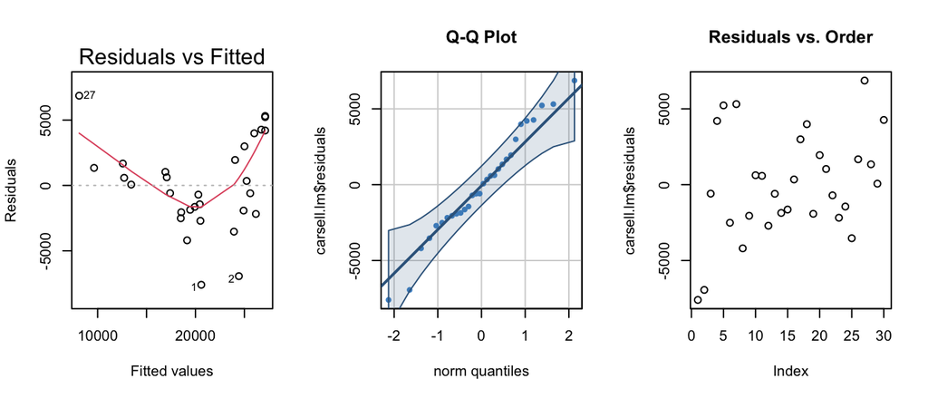

```r
carsell.lm <- lm(Price ~ Mileage, data=carselling)

par(mfrow=c(1,3))

plot(carsell.lm, which=1)

qqPlot(carsell.lm$residuals, main="Q-Q Plot", col="steelblue3", col.lines="steelblue4", pch= 19, id=FALSE)

plot(carsell.lm$residuals, main = "Residuals vs. Order")
```

There are 5 associated assumptions to the linear regression. All but #4 can be checked with these above plots.

**Assumption 1: Linear Relationship Between X and Y**

**Assumption 2: Normal Distribution of Error Terms**

We can see a slight skew in the normality of the data as shown in the Q-Q plot. This does not affect the outcome of this model.

**Assumption 3: Constant Variance (X values)**

**Assumption 4: Fixed X Values**

We can assume the prices and mileages of the cars are accurate and consistent measurements of actual prices of HR-V cars.

**Assumption 5: Independent Error Terms**

The Residuals vs Order plot shows the chaos in the data. Error terms do not appear to be correlated. There is not a clear pattern in the plot.

: )

**Appendix**

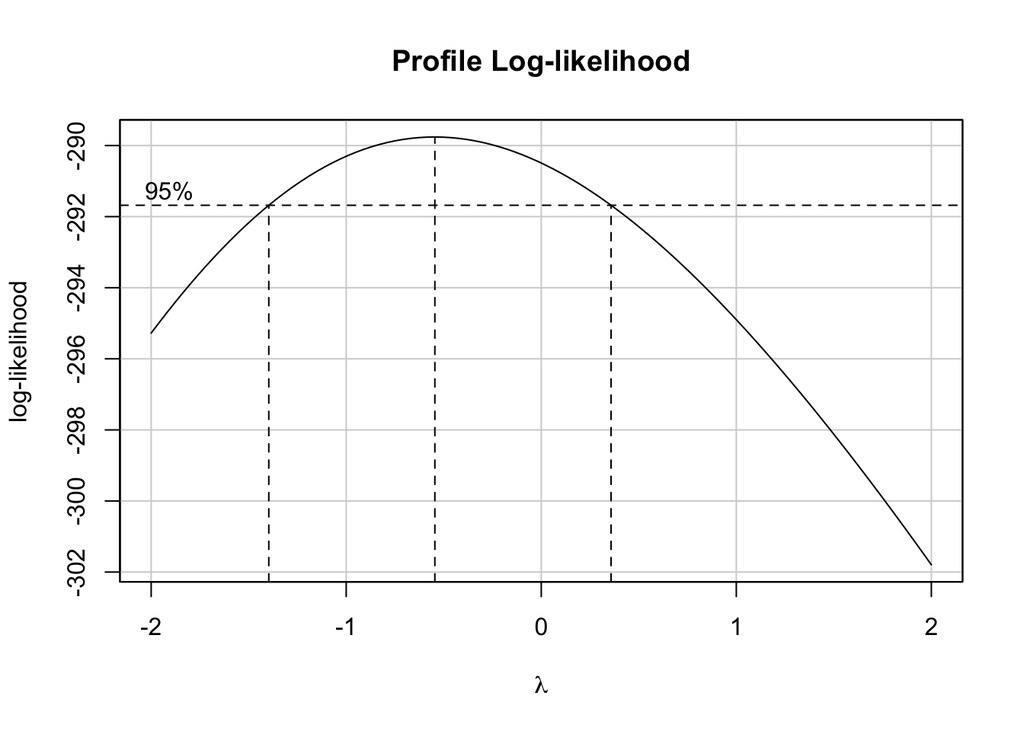

```r
boxCox(carsell.lm)
```

I’m going to run a log because of this boxCox assumption

: )

###### Credits

Thank you Brother Saunders for helping with the codes on Friday to make the boxCox and different lines.

Back to top